# COVID Impact on U.S. Flight Behavior

Bernice Yuan

2025-04-04

## Introduction

The COVID-19 pandemic, which began impacting the United States in early 2020, drastically altered patterns of human mobility. One of the most affected industries was aviation, with widespread travel restrictions, stay-at-home orders, and shifting consumer behavior causing sharp declines in both domestic and international air travel.

This project investigates the impact of COVID-19 on flight behavior across the five busiest U.S. airports: Hartsfield–Jackson Atlanta International Airport (ATL), Los Angeles International Airport (LAX), Denver International Airport (DEN), Dallas/Fort Worth International Airport (DFW), and Chicago O’Hare International Airport (ORD). Together, these airports serve as major hubs for both business and leisure travel and provide a representative lens through which to understand broader national mobility trends.

```r
# Create folders for output if not exist
if (!dir.exists("plots")) dir.create("plots")
flights <- read_csv("data/Top5airportsUS.csv") %>%
    drop_na()
covid <- read_csv("data/Top5StateCovid.csv")
```

## Research Question 1

### How does the pandemic impact the total flights in these 5 top airports in the US by comparing year 2019 and 2020?

```r
flight_summary <- flights %>%
    filter(year %in% c(2019, 2020)) %>%
    group_by(origin, year) %>%
    summarise(total_flights = n(), .groups = "drop") %>%
    pivot_wider(names_from = year, values_from = total_flights, names_prefix = "year_") %>%
    mutate(percent_change = (year_2020 - year_2019) / year_2019 * 100)

print(flight_summary)
```

```
## # A tibble: 5 × 4
##   origin year_2019 year_2020 percent_change
##   <chr>      <int>     <int>          <dbl>
## 1 ATL       391701    242932          -38.0
## 2 DEN       246477    187105          -24.1
## 3 DFW       295645    213553          -27.8
## 4 LAX       216481    117646          -45.7
## 5 ORD       328129    177563          -45.9
```

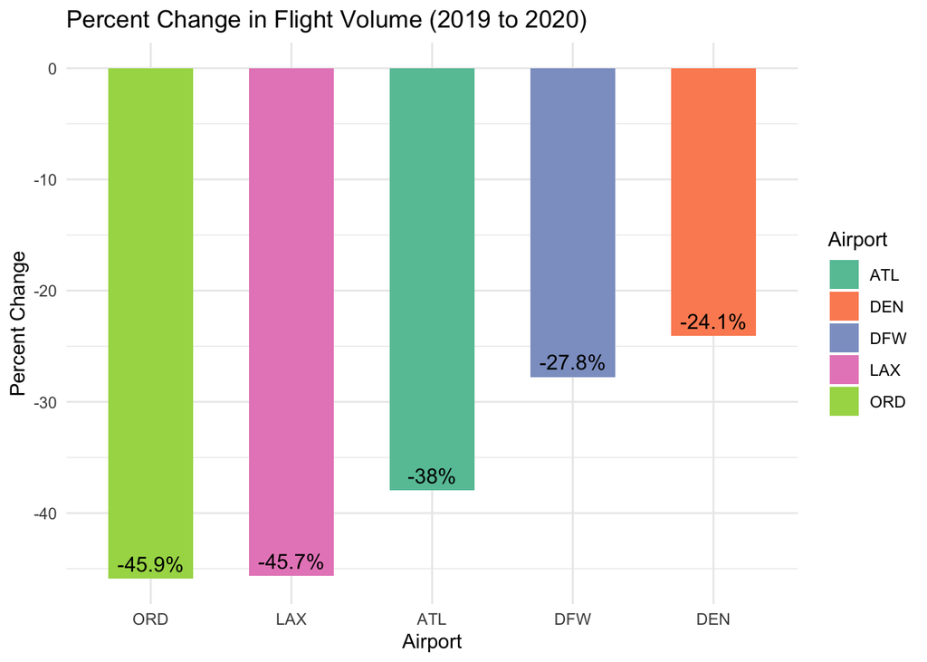

```r
p <- ggplot(flight_summary, aes(x = reorder(origin, percent_change), y = percent_change, fill = origin)) +
    geom_col(width = 0.6) +
    geom_text(aes(label = paste0(round(percent_change, 1), "%")),
        vjust = -0.5, size = 4
    ) +
    scale_fill_brewer(palette = "Set2") +
    labs(
        title = "Percent Change in Flight Volume (2019 to 2020)",
        x = "Airport",
        y = "Percent Change",
        fill = "Airport"
    ) +
    theme_minimal()

print(p)
```

```r
ggsave("plots/flight_percent_change.png", width = 8, height = 5)
```

### Summary for Research Question 1

The COVID-19 pandemic caused a significant decline in flight volumes across all five of the busiest U.S. airports between 2019 and 2020. The steepest drops were observed at ORD (Chicago O’Hare) and LAX (Los Angeles), with decreases of -45.9% and -45.7% respectively. ATL (Atlanta) also experienced a substantial reduction of -38%. In contrast, DFW (Dallas/Fort Worth) and DEN (Denver) had comparatively smaller declines at -27.8% and -24.1%, suggesting these hubs maintained a relatively higher volume of flights during the pandemic. These patterns highlight how the impact of COVID-19 on air travel varied significantly across regions.

## Research Question 2

### How did the COVID-19 pandemic impact flight activity in relation to the number of COVID cases across states?

```r
states <- c("GA", "CA", "CO", "TX", "FL")

covid_monthly <- covid %>%
    mutate(date = ymd(date), state = toupper(state)) %>%
    filter(state %in% states, year(date) == 2020, day(date) == days_in_month(date)) %>%
    select(state, date, positive) %>%
    arrange(state, date)
print(covid_monthly)
```

```
## # A tibble: 50 × 3
##    state date       positive
##    <chr> <date>        <dbl>
##  1 CA    2020-03-31     7482
##  2 CA    2020-04-30    48917
##  3 CA    2020-05-31   110583
##  4 CA    2020-06-30   228732
##  5 CA    2020-07-31   493588
##  6 CA    2020-08-31   704085
##  7 CA    2020-09-30   810625
##  8 CA    2020-10-31   922005
##  9 CA    2020-11-30  1212968
## 10 CA    2020-12-31  2245379
## # ℹ 40 more rows
```

```r
flights_filtered <- flights %>%
    mutate(
        date = make_date(year, month, day),
        state = case_when(
            origin == "ATL" ~ "GA",
            origin == "LAX" ~ "CA",
            origin == "DEN" ~ "CO",
            origin == "DFW" ~ "TX",
            origin == "ORD" ~ "FL"
        )
    ) %>%
    filter(year == 2020, state %in% states, date >= as.Date("2020-03-04")) %>%
    mutate(month_end = ceiling_date(date, "month") - days(1)) %>%
    filter(month_end <= as.Date("2020-12-31"))

flight_monthly <- flights_filtered %>%
    group_by(state, month_end) %>%
    summarise(monthly_flights = n(), .groups = "drop") %>%
    rename(date = month_end)

covid_flight_2020 <- left_join(flight_monthly, covid_monthly, by = c("state", "date"))
print(covid_flight_2020)
```

```
## # A tibble: 50 × 4
##    state date       monthly_flights positive
##    <chr> <date>               <int>    <dbl>
##  1 CA    2020-03-31           13711     7482
##  2 CA    2020-04-30            4530    48917
##  3 CA    2020-05-31            3727   110583
##  4 CA    2020-06-30            5100   228732
##  5 CA    2020-07-31            8625   493588
##  6 CA    2020-08-31            9366   704085
##  7 CA    2020-09-30            8227   810625
##  8 CA    2020-10-31            9022   922005
##  9 CA    2020-11-30            9410  1212968
## 10 CA    2020-12-31            9979  2245379
## # ℹ 40 more rows
```

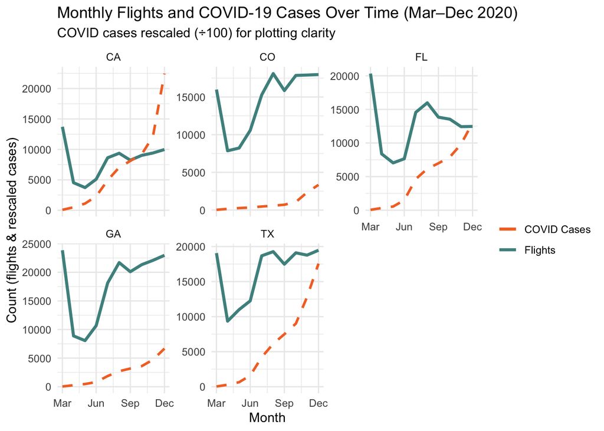

```r
covid_flight_2020_labeled <- covid_flight_2020 %>%
    mutate(month = format(date, "%b"))

ggplot(covid_flight_2020_labeled, aes(x = date)) +
    geom_line(aes(y = monthly_flights, color = "Flights"), size = 1.2) +
    geom_line(aes(y = positive / 100, color = "COVID Cases"), linetype = "dashed", size = 1) +
    facet_wrap(~state, scales = "free_y") +
    scale_color_manual(values = c("Flights" = "#4D908E", "COVID Cases" = "#F3722C")) +
    scale_x_date(
        breaks = as.Date(c("2020-03-31", "2020-06-30", "2020-09-30", "2020-12-31")),
        labels = c("Mar", "Jun", "Sep", "Dec")
    ) +
    labs(
        title = "Monthly Flights and COVID-19 Cases Over Time (Mar–Dec 2020)",
        subtitle = "COVID cases rescaled (÷100) for plotting clarity",
        x = "Month",
        y = "Count (flights & rescaled cases)",
        color = ""
    ) +
    theme_minimal()
```

```r
ggsave("plots/all_states_flight_vs_covid_scatter.png", width = 10, height = 8)
```

## Research Question 3

### How resilient were major U.S. airports in recovering flight volumes during the pandemic, and which state rebounded the strongest between March and December 2020?

```r
# Step 1: Get March flight volumes
march_volume <- covid_flight_2020_labeled %>%
    filter(month == "Mar") %>%
    select(state, mar_volume = monthly_flights)

# Step 2: For each state, find min volume (Apr–Dec) and recovery duration
resilience_analysis <- covid_flight_2020_labeled %>%
    filter(!(month %in% c("Mar"))) %>%
    mutate(month_num = as.integer(format(date, "%m"))) %>%
    left_join(march_volume, by = "state") %>%
    group_by(state) %>%
    mutate(
        drop_pct = (min(monthly_flights) - mar_volume) / mar_volume * 100,
        recovery_threshold = mar_volume * 0.8,
        recovered = monthly_flights >= recovery_threshold
    ) %>%
    summarise(
        mar_volume = first(mar_volume),
        min_volume = min(monthly_flights),
        drop_pct = first(drop_pct),
        months_to_80pct = ifelse(any(recovered), min(month_num[recovered]) - 3, Inf),
        max_flights = max(monthly_flights),
        max_month = format(date[which.max(monthly_flights)], "%b"),
        resilience_score = ifelse(is.finite(months_to_80pct),
            (1 / months_to_80pct) * (100 + drop_pct),
            0
        )
    )

resilience_analysis <- resilience_analysis %>%
    rename(
        `March Volume` = mar_volume,
        `Min Volume` = min_volume,
        `Percentage Dropped` = drop_pct,
        `Months to 80%` = months_to_80pct,
        `Max Volume` = max_flights,
        `Max Month` = max_month,
        `Resilience Score` = resilience_score
    )


knitr::kable(
    resilience_analysis,
    digits = 2,
    caption = "Resilience, Drop Percentage, and Peak Month by State (Mar–Dec 2020)",
    align = "c" # Center all columns
)
```

Resilience, Drop Percentage, and Peak Month by State (Mar–Dec 2020)

| state | March Volume | Min Volume | Percentage Dropped | Months to 80% | Max Volume | Max Month | Resilience Score |
| --- | --- | --- | --- | --- | --- | --- | --- |
| CA | 13711 | 3727 | -72.82 | Inf | 9979 | Dec | 0.00 |
| CO | 15983 | 7861 | -50.82 | 4 | 18100 | Aug | 12.30 |
| FL | 20333 | 7040 | -65.38 | Inf | 15982 | Aug | 0.00 |
| GA | 23855 | 8060 | -66.21 | 5 | 22971 | Dec | 6.76 |
| TX | 19061 | 9352 | -50.94 | 4 | 19468 | Dec | 12.27 |

### Summary for Research Question 3

To evaluate the resilience of air travel across five major U.S. states, we developed a resilience score that incorporates both the magnitude of decline and the speed of recovery in flight activity following the onset of COVID-19. The percent drop was calculated as the difference between each state’s March 2020 flight volume and its lowest monthly volume between April and December 2020. Recovery was measured by the number of months it took for flight volume to return to at least 80% of March levels.

The resilience score is defined as:

$$\text{Resilience Score} = \left(\frac{1}{\text{months to 80%}}\right)
\times (100 + \text{Percentage Dropped})$$

This metric rewards states that recovered quickly and experienced shallower declines. States that never recovered to the 80% threshold received a resilience score of 0.

These results align with the broader trends observed in flight activity over time, particularly highlighting Denver International Airport (DEN) in Colorado. DEN demonstrated a sharp recovery and peaked in August 2020, showcasing one of the strongest and earliest rebounds among the five states analyzed.